# VAR Demonstration

Two packages are very useful for VAR in R, MSBVAR and vars. First load the MSBVAR package, and we will continue using the same data.

```
library(MSBVAR)
data(BCFData)
```

## vars package

Next load the vars library. Note that this overwrites the irf function in MSBVAR, we will deal with this later.

```r
library(vars)
```

We can plot the series again.

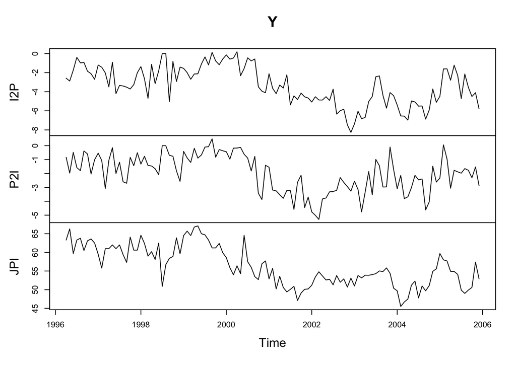

```r
#plot
plot(Y)
```

If we know we want to do a VAR analysis, with these three series, then we still need to know p, the lag length to use. We can check different specifications using this command:

```r
#lag specification
VARselect(Y, lag.max=15, type="const")
```

```
## $selection
## AIC(n)  HQ(n)  SC(n) FPE(n)
##      2      2      1      2
##
## $criteria
##             1      2      3      4      5      6      7      8      9
## AIC(n)  2.436  2.326  2.344  2.453  2.523  2.499  2.551  2.653  2.651
## HQ(n)   2.561  2.545  2.657  2.859  3.023  3.093  3.239  3.435  3.526
## SC(n)   2.744  2.867  3.116  3.457  3.758  3.966  4.250  4.583  4.812
## FPE(n) 11.424 10.247 10.441 11.672 12.566 12.330 13.091 14.642 14.790
##            10     11     12     13     14     15
## AIC(n)  2.667  2.755  2.759  2.829  2.846  2.937
## HQ(n)   3.636  3.818  3.916  4.079  4.190  4.375
## SC(n)   5.060  5.380  5.616  5.917  6.166  6.488
## FPE(n) 15.275 17.027 17.516 19.337 20.371 23.254
```

Make sure you understand the output. The AIC and BIC are most useful criterion to think about.

Once we have a lag length – 3 is a reasonable and conservative choice here for now– we want to estimate the reduced form VAR.

```r
#estimate reduced form

rf.var0<-VAR(Y, p=3, type="const")

summary(rf.var0)
```

```
##
## VAR Estimation Results:
## =========================
## Endogenous variables: I2P, P2I, JPI
## Deterministic variables: const
## Sample size: 114
## Log Likelihood: -582.696
## Roots of the characteristic polynomial:
## 0.938 0.744 0.672 0.659 0.659 0.493 0.248 0.248 0.0722
## Call:
## VAR(y = Y, p = 3, type = "const")
##
##
## Estimation results for equation I2P:
## ====================================
## I2P = I2P.l1 + P2I.l1 + JPI.l1 + I2P.l2 + P2I.l2 + JPI.l2 + I2P.l3 + P2I.l3 + JPI.l3 + const
##
##        Estimate Std. Error t value Pr(>|t|)
## I2P.l1   0.3691     0.1037    3.56  0.00056 ***
## P2I.l1   0.0869     0.1266    0.69  0.49422
## JPI.l1   0.0198     0.0389    0.51  0.61145
## I2P.l2   0.2209     0.1021    2.16  0.03279 *
## P2I.l2  -0.2897     0.1334   -2.17  0.03211 *
## JPI.l2   0.1541     0.0432    3.57  0.00055 ***
## I2P.l3   0.0640     0.0969    0.66  0.51031
## P2I.l3   0.2284     0.1270    1.80  0.07506 .
## JPI.l3  -0.0611     0.0438   -1.39  0.16631
## const   -7.4744     2.2039   -3.39  0.00098 ***
## ---
## Signif. codes:  0 '***' 0.001 '**' 0.01 '*' 0.05 '.' 0.1 ' ' 1
##
##
## Residual standard error: 1.13 on 104 degrees of freedom
## Multiple R-Squared: 0.714,   Adjusted R-squared: 0.69
## F-statistic: 28.9 on 9 and 104 DF,  p-value: <2e-16
##
##
## Estimation results for equation P2I:
## ====================================
## P2I = I2P.l1 + P2I.l1 + JPI.l1 + I2P.l2 + P2I.l2 + JPI.l2 + I2P.l3 + P2I.l3 + JPI.l3 + const
```

[output cut: 42 more lines]

```
## F-statistic: 31.1 on 9 and 104 DF,  p-value: <2e-16
##
##
##
## Covariance matrix of residuals:
##         I2P    P2I     JPI
## I2P  1.2853 0.3566 -0.0733
## P2I  0.3566 0.8040  0.0238
## JPI -0.0733 0.0238  8.0356
##
## Correlation matrix of residuals:
##         I2P     P2I      JPI
## I2P  1.0000 0.35077 -0.02281
## P2I  0.3508 1.00000  0.00936
## JPI -0.0228 0.00936  1.00000
```

We can get a nice plot of this object with:

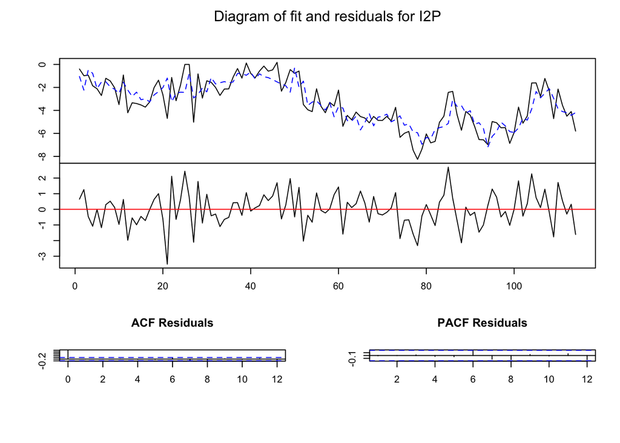

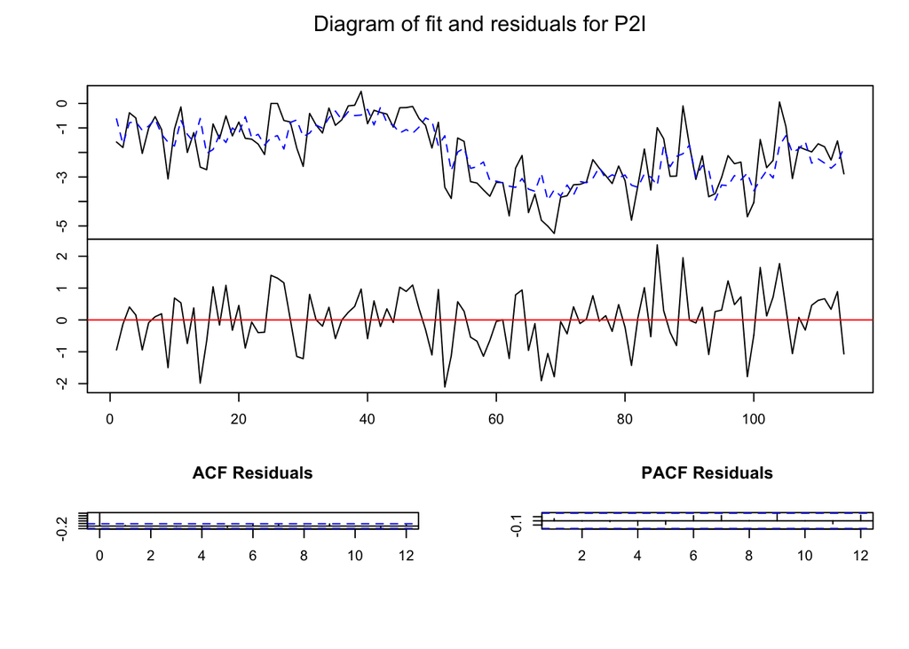

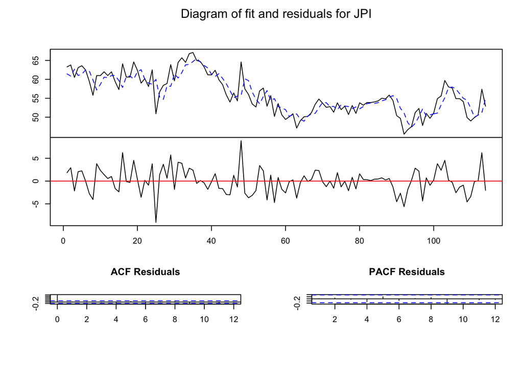

```r
plot(rf.var0)
```

The coefficients are not of obvious interest, but the impulse response functions are.

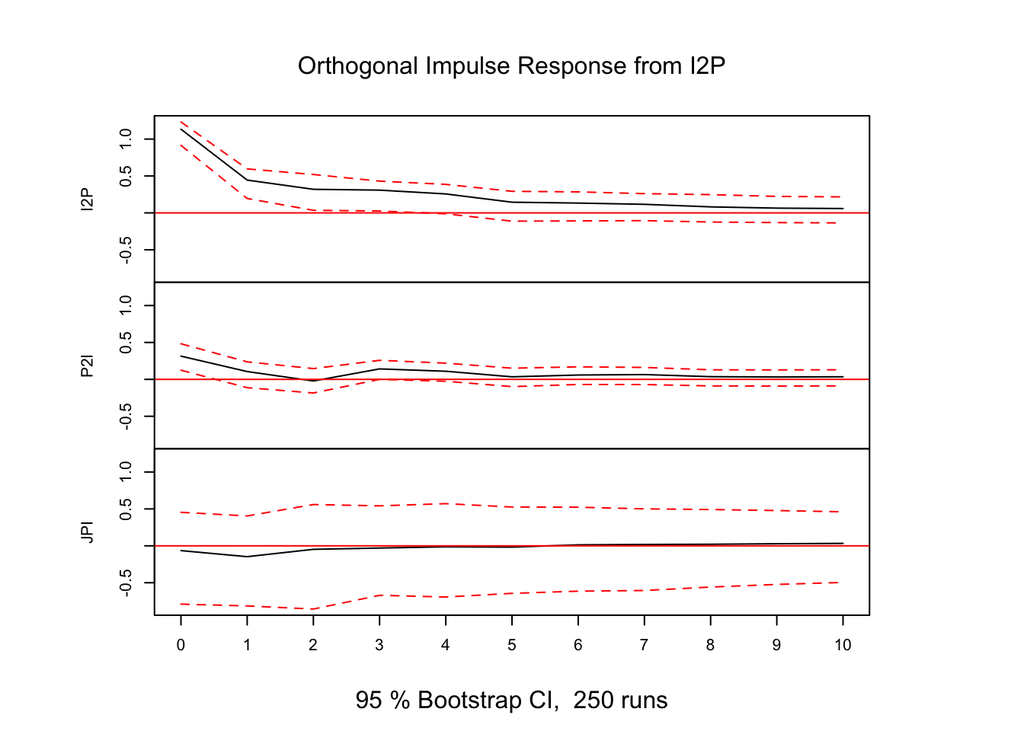

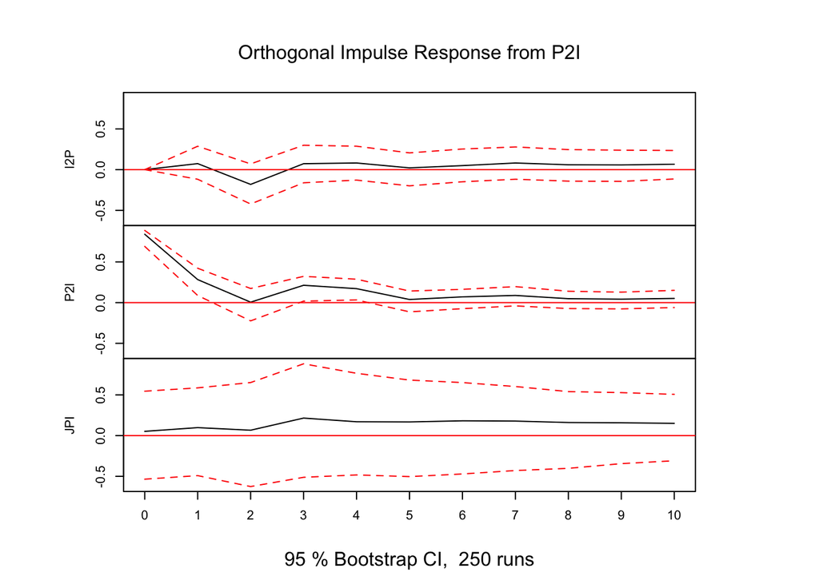

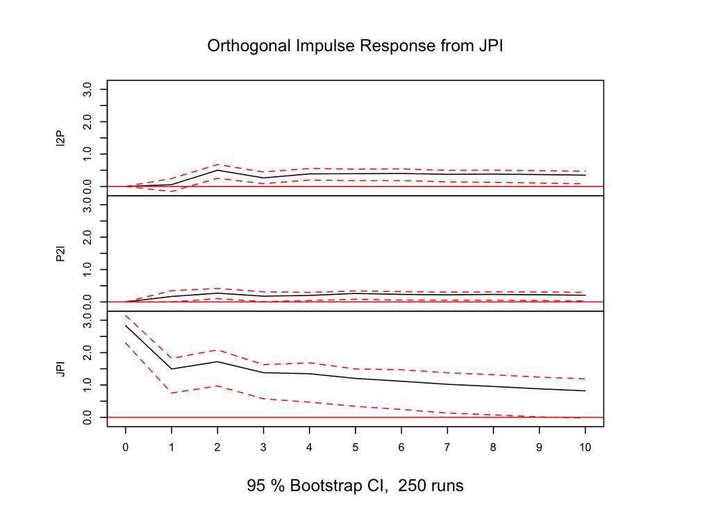

```r
#IRFs
irf(rf.var0, ortho= TRUE, boot=TRUE, ci=.95, runs=250, cumulative=FALSE) %>% plot()
```

It is importat to note that the confidence intervals are bootstapped here and need more samples.

Can also do residual diagnostic tests quickly.

```r
#Normality test
normality.test(rf.var0)
```

```
## $JB
##
##  JB-Test (multivariate)
##
## data:  Residuals of VAR object rf.var0
## Chi-squared = 7.734, df = 6, p-value = 0.2583
##
##
## $Skewness
##
##  Skewness only (multivariate)
##
## data:  Residuals of VAR object rf.var0
## Chi-squared = 1.463, df = 3, p-value = 0.6908
##
##
## $Kurtosis
##
##  Kurtosis only (multivariate)
##
## data:  Residuals of VAR object rf.var0
## Chi-squared = 6.271, df = 3, p-value = 0.09917
```

```r
#Serial correlation
serial.test(rf.var0)
```

```
##
##  Portmanteau Test (asymptotic)
##
## data:  Residuals of VAR object rf.var0
## Chi-squared = 113.3, df = 117, p-value = 0.5803
```

## MSBVAR package

Can do similar things in the MSBVAR package, but it also extends to a greater set of models.

In MSBVAR, lag selection is done by:

```r
#lag specification
var.lag.specification(Y, lagmax=15)
```

```
## $ldets
##       Lags Log-Det  Chi^2  p-value
##  [1,]   15  0.2309  4.794 0.851890
##  [2,]   14  0.3165  9.405 0.400786
##  [3,]   13  0.4759  6.631 0.675430
##  [4,]   12  0.5829 11.212 0.261433
##  [5,]   11  0.7554  5.973 0.742593
##  [6,]   10  0.8432 11.385 0.250264
##  [7,]    9  1.0036 13.260 0.151203
##  [8,]    8  1.1828  5.728 0.766781
##  [9,]    7  1.2571  9.923 0.356733
## [10,]    6  1.3812 16.665 0.054230
## [11,]    5  1.5820  9.146 0.423914
## [12,]    4  1.6883  5.992 0.740739
## [13,]    3  1.7556 14.622 0.101853
```

[output cut: 23 more lines]

```r
var.lag.specification(Y, lagmax=8)
```

```
## $ldets
##      Lags Log-Det  Chi^2   p-value
## [1,]    8   1.169  6.992 0.6379633
## [2,]    7   1.252 10.788 0.2904889
## [3,]    6   1.376 17.015 0.0484837
## [4,]    5   1.565 10.426 0.3171362
## [5,]    4   1.677  5.557 0.7832911
## [6,]    3   1.735 17.047 0.0479913
## [7,]    2   1.907 31.720 0.0002226
## [8,]    1   2.218  0.000 0.0000000
##
## $results
##      Lags   AIC   BIC    HQ
## [1,]    1 2.439 2.735 2.559
## [2,]    2 2.293 2.811 2.503
## [3,]    3 2.286 3.026 2.586
## [4,]    4 2.393 3.356 2.783
## [5,]    5 2.446 3.631 2.927
## [6,]    6 2.422 3.829 2.993
## [7,]    7 2.463 4.093 3.124
## [8,]    8 2.545 4.397 3.296
##
## attr(,"class")
## [1] "var.lag.specification"
```

```r
var.lag.specification(Y, lagmax=6)
```

```
## $ldets
##      Lags Log-Det Chi^2   p-value
## [1,]    6   1.368 16.11 0.0645466
## [2,]    5   1.543 11.05 0.2725144
## [3,]    4   1.659  5.97 0.7429480
## [4,]    3   1.720 17.78 0.0378385
## [5,]    2   1.896 31.75 0.0002196
## [6,]    1   2.201  0.00 0.0000000
##
## $results
##      Lags   AIC   BIC    HQ
## [1,]    1 2.418 2.710 2.536
## [2,]    2 2.274 2.787 2.482
## [3,]    3 2.260 2.993 2.558
## [4,]    4 2.362 3.314 2.748
## [5,]    5 2.408 3.579 2.883
## [6,]    6 2.395 3.786 2.959
##
## attr(,"class")
## [1] "var.lag.specification"
```

A reduced form, frequentist VAR is done by:

```r
#Reduced form frequentist VAR

rf.var1 <- reduced.form.var(Y, p=3)
```

We can access the coefficients and vcov matrix by:

```r
#where are coefs?

#intercepts?
rf.var1$intercept
```

```
## [1] -7.474 -5.359  8.020
```

```r
#ars?
rf.var1$ar.coef
```

```
## , , 1
##
##         [,1]    [,2]     [,3]
## [1,] 0.36910 0.00422 -0.12279
## [2,] 0.08685 0.33337  0.08404
## [3,] 0.01981 0.05929  0.52775
##
## , , 2
##
##         [,1]      [,2]     [,3]
## [1,]  0.2209 -0.009739  0.09124
## [2,] -0.2897 -0.115860 -0.02051
## [3,]  0.1541  0.044099  0.32574
##
## , , 3
##
##          [,1]     [,2]       [,3]
## [1,]  0.06399  0.07318 -0.0003757
## [2,]  0.22844  0.28391  0.1480780
## [3,] -0.06107 -0.02213  0.0078233
```

```r
#Betahats?
rf.var1$Bhat
```

```
##           [,1]      [,2]       [,3]
##  [1,]  0.36910  0.004220 -0.1227917
##  [2,]  0.08685  0.333370  0.0840444
##  [3,]  0.01981  0.059287  0.5277530
##  [4,]  0.22086 -0.009739  0.0912426
##  [5,] -0.28970 -0.115860 -0.0205105
##  [6,]  0.15406  0.044099  0.3257431
##  [7,]  0.06399  0.073184 -0.0003757
##  [8,]  0.22844  0.283908  0.1480780
##  [9,] -0.06107 -0.022134  0.0078233
## [10,] -7.47438 -5.358809  8.0195279
```

```r
#vcov
rf.var1$vcv
```

```
##          [,1]    [,2]     [,3]
## [1,]  1.17256 0.32530 -0.06686
## [2,]  0.32530 0.73344  0.02169
## [3,] -0.06686 0.02169  7.33076
```

Can also get a summary:

```r
#summmary
summary(rf.var1)
```

```
## ==========================================
## Reduced Form VAR
## ==========================================
## Number of observations :     114
## Degrees of freedom per equation :     104
## ------------------------------------------
## Autoregressive Matrices:
## B(1)
##         [,1]    [,2]     [,3]
## [1,] 0.36910 0.00422 -0.12279
## [2,] 0.08685 0.33337  0.08404
## [3,] 0.01981 0.05929  0.52775
##
## B(2)
##         [,1]      [,2]     [,3]
## [1,]  0.2209 -0.009739  0.09124
## [2,] -0.2897 -0.115860 -0.02051
## [3,]  0.1541  0.044099  0.32574
##
## B(3)
##          [,1]     [,2]      [,3]
## [1,]  0.06399  0.07318 -0.000376
## [2,]  0.22844  0.28391  0.148078
## [3,] -0.06107 -0.02213  0.007823
##
## ------------------------------------------
## Constants :
## -7.474   -5.359  8.02
## ------------------------------------------
## Posterior error covariance:
##          [,1]    [,2]     [,3]
## [1,]  1.17256 0.32530 -0.06686
## [2,]  0.32530 0.73344  0.02169
## [3,] -0.06686 0.02169  7.33076
## ------------------------------------------
```

We can plot irfs, using the MSBVAR irf function (need to look in MSBVAR namespace):

```
##         [,1]     [,2]    [,3]
## [1,] -0.1732 -0.02091 -0.1403
## [2,]  1.0829  0.80200  2.7064
```

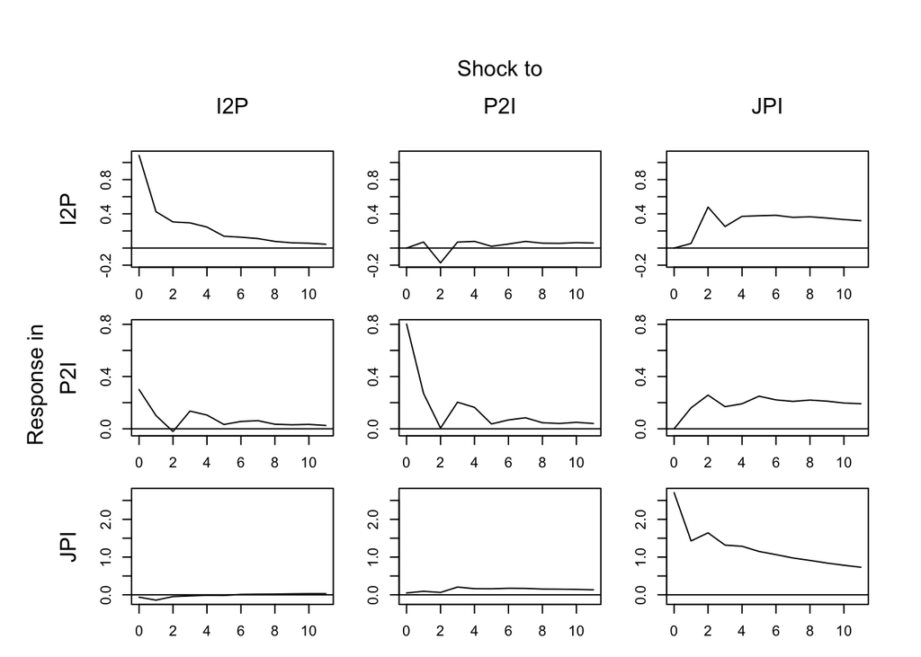

```r
#Check IRFs?, use MSBVAR irf function (vars has one too, same name!)
MSBVAR::irf(rf.var1, nsteps=12) %>% plot()
```

Can change confidence intervals:

```
## Monte Carlo IRF Iteration = 1000
## Monte Carlo IRF Iteration = 2000
## Monte Carlo IRF Iteration = 3000
## Monte Carlo IRF Iteration = 4000
## Monte Carlo IRF Iteration = 5000
```

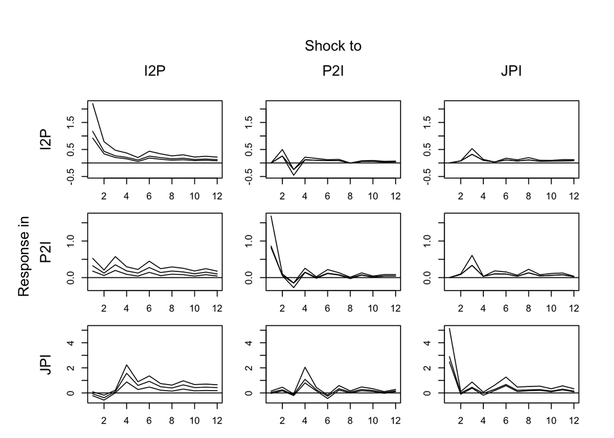

```r
#Try
mc.irf(rf.var1, draws=5000, nsteps=12) %>% plot(, probs=c(.05,.95))
```

Can you interpret this?